# US zipcodes and co-ordinates

I have picked US zipcodes dataset to for this assignment to provide the description. In this I have also added my work related to the homework assignment.

```python
import pandas as pd
import matplotlib.pyplot as plt
```

# Data Description

The data which is used in this assignment is a simple and accurate database of US zipcodes. This dataset is built using sources like U.S Postal Service, U.S Census Bureau, National Weather Service, American Community Survey and IRS. This dataset contains a total of 18 attributes. zipcode, lattitude, longitude, city, state, timezone, population are some of those attributes. The values in this dataset include integers, floating point numbers, strings and boolean values.

Here is the link to the raw file of this dataset https://raw.githubusercontent.com/Vishal2610/datasets/master/uszips.csv

For this I have Python langauage and matplotlib library to plot all the zipcodes.

```python
data = pd.read_csv('https://raw.githubusercontent.com/Vishal2610/datasets/master/uszips.csv')
```

```python
data.head()
```

|  | zip | lat | lng | city | state_id | state_name | zcta | parent_zcta | population | density | county_fips | county_name | county_weights | county_names_all | county_fips_all | imprecise | military | timezone |
| --- | --- | --- | --- | --- | --- | --- | --- | --- | --- | --- | --- | --- | --- | --- | --- | --- | --- | --- |
| 0 | 601 | 18.18004 | -66.75218 | Adjuntas | PR | Puerto Rico | True | NaN | 17242 | 111.4 | 72001 | Adjuntas | {'72001':99.43,'72141':0.57} | Adjuntas\|Utuado | 72001\|72141 | False | False | America/Puerto_Rico |
| 1 | 602 | 18.36073 | -67.17517 | Aguada | PR | Puerto Rico | True | NaN | 38442 | 523.5 | 72003 | Aguada | {'72003':100} | Aguada | 72003 | False | False | America/Puerto_Rico |
| 2 | 603 | 18.45439 | -67.12202 | Aguadilla | PR | Puerto Rico | True | NaN | 48814 | 667.9 | 72005 | Aguadilla | {'72005':100} | Aguadilla | 72005 | False | False | America/Puerto_Rico |
| 3 | 606 | 18.16724 | -66.93828 | Maricao | PR | Puerto Rico | True | NaN | 6437 | 60.4 | 72093 | Maricao | {'72093':94.88,'72121':1.35,'72153':3.78} | Maricao\|Yauco\|Sabana Grande | 72093\|72153\|72121 | False | False | America/Puerto_Rico |
| 4 | 610 | 18.29032 | -67.12243 | Anasco | PR | Puerto Rico | True | NaN | 27073 | 312.0 | 72011 | Añasco | {'72003':0.55,'72011':99.45} | Añasco\|Aguada | 72011\|72003 | False | False | America/Puerto_Rico |

Here is the plot of zipcodes along with the coordinates of all the states of US

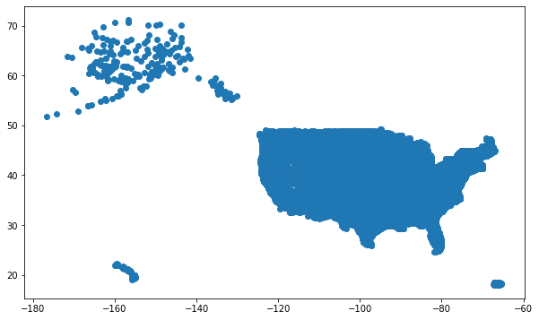

```python
fig, ax = plt.subplots(figsize=(10,6))
ax.scatter(data['lng'], data['lat'])
plt.show()
```

Got rid of zipcodes from the states Alaska, Hawaii, Puerto Rico

```python
data = data[data.state_id != 'PR']
data = data[data.state_id != 'AK']
data = data[data.state_id != 'HI']
data.head()
```

|  | zip | lat | lng | city | state_id | state_name | zcta | parent_zcta | population | density | county_fips | county_name | county_weights | county_names_all | county_fips_all | imprecise | military | timezone |
| --- | --- | --- | --- | --- | --- | --- | --- | --- | --- | --- | --- | --- | --- | --- | --- | --- | --- | --- |
| 131 | 1001 | 42.06258 | -72.62590 | Agawam | MA | Massachusetts | True | NaN | 17621 | 562.8 | 25013 | Hampden | {'25013':100} | Hampden | 25013 | False | False | America/New_York |
| 132 | 1002 | 42.37492 | -72.46210 | Amherst | MA | Massachusetts | True | NaN | 30066 | 203.7 | 25015 | Hampshire | {'25011':0.97,'25015':99.03} | Hampshire\|Franklin | 25015\|25011 | False | False | America/New_York |
| 133 | 1003 | 42.39192 | -72.52479 | Amherst | MA | Massachusetts | True | NaN | 11238 | 5629.7 | 25015 | Hampshire | {'25015':100} | Hampshire | 25015 | False | False | America/New_York |
| 134 | 1005 | 42.42018 | -72.10615 | Barre | MA | Massachusetts | True | NaN | 4991 | 44.3 | 25027 | Worcester | {'25027':100} | Worcester | 25027 | False | False | America/New_York |
| 135 | 1007 | 42.27875 | -72.40036 | Belchertown | MA | Massachusetts | True | NaN | 14967 | 107.5 | 25015 | Hampshire | {'25015':100} | Hampshire | 25015 | False | False | America/New_York |

Here is the rough map of United States without Hawaii, Alaska and Puerto Rico

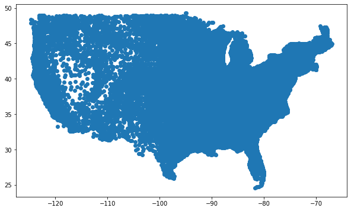

```python
fig, ax = plt.subplots(figsize=(10,6))
ax.scatter(data['lng'], data['lat'])
plt.show()
```